# Demonstration: Regional Skills-Gap Divergence Score for Electricians

FIT5145 Assignment 3 - Characterising and Analysing Data: Demonstration

Chinni Raja Ammela (36309591)

03 October 2026

## 1. Purpose

This notebook demonstrates the feasibility of the regional skills-gap early-warning system proposed in the project report. It uses **Electricians (ANZSCO 3411)** as a worked example occupation, combining:

- **Demand side**: Jobs and Skills Australia’s Internet Vacancy Index (IVI), monthly online jobs advertisement counts by occupation and JSA Remoteness classification.
- **Supply side**: NCVER’s Total VET students and courses 2025 program completions, for the Electrotechnology (UEE, UTE, UTL) training package, by remoteness region.

Both datasets are publicly available. Download links and access notes are provided in section 2.

## 2. Data sources

| Dataset | Source | Access | Link |
| --- | --- | --- | --- |
| Internet Vacancy Index | Jobs and Skills Australia | Free, no login, direct Excel download | https://www.jobsandskills.gov.au/data/internet-vacancy-index |
| Total VET students and courses 2025: program completions | NCVER DataBuilder | Free, no login, interactive table export | https://www.ncver.edu.au/research-and-statistics/data/databuilder |

## 3. Loading and reshaping the data

### 3.1 Internet Vacancy Index (demand side)

```r
ivi_path <- "internet_vacancies_anzsco4_occupations_jsa_remoteness_and_northern_australia_classification_-_august_2026.xlsx"

ivi_raw <- read_excel(ivi_path, sheet = "JSA Remoteness", col_names = TRUE)

# Filter to Electricians (ANZSCO 3411), reshape from wide (one column per month)
# to long format, and derive calendar year from the Excel date serial number.
elec_ivi <- ivi_raw %>%
  filter(ANZSCO_CODE == "3411") %>%
  select(-Level, -ANZSCO_CODE, -ANZSCO_TITLE) %>%
  rename(remoteness = `JSA Remoteness`) %>%
  pivot_longer(-remoteness, names_to = "date_serial", values_to = "vacancies") %>%
  mutate(
    date = as.Date(as.numeric(date_serial), origin = "1899-12-30"),
    year = year(date)
  )
glimpse(elec_ivi)
```

```
## Rows: 184
## Columns: 5
## $ remoteness  <chr> "Regional", "Regional", "Regional", "Regional", "Regional"…
## $ date_serial <chr> "43466", "43497", "43525", "43556", "43586", "43617", "436…
## $ vacancies   <dbl> 645, 634, 727, 682, 671, 626, 661, 658, 683, 677, 663, 588…
## $ date        <date> 2019-01-01, 2019-02-01, 2019-03-01, 2019-04-01, 2019-05-0…
## $ year        <dbl> 2019, 2019, 2019, 2019, 2019, 2019, 2019, 2019, 2019, 2019…
```

### 3.2 Exploratory check: data coverage and seasonality

```r
# Check monthly coverage is complete (no missing months) before aggregating to
# annual totals - an incomplete year would bias the annual sum downward.
coverage <- elec_ivi %>%
  filter(year >= 2019, year <= 2025) %>%
  count(remoteness, year, name = "n_months")

print(coverage, n = 20)
```

```
## # A tibble: 14 × 3
##    remoteness  year n_months
##    <chr>      <dbl>    <int>
##  1 Major City  2019       12
##  2 Major City  2020       12
##  3 Major City  2021       12
##  4 Major City  2022       12
##  5 Major City  2023       12
##  6 Major City  2024       12
##  7 Major City  2025       12
##  8 Regional    2019       12
##  9 Regional    2020       12
## 10 Regional    2021       12
## 11 Regional    2022       12
## 12 Regional    2023       12
## 13 Regional    2024       12
## 14 Regional    2025       12
```

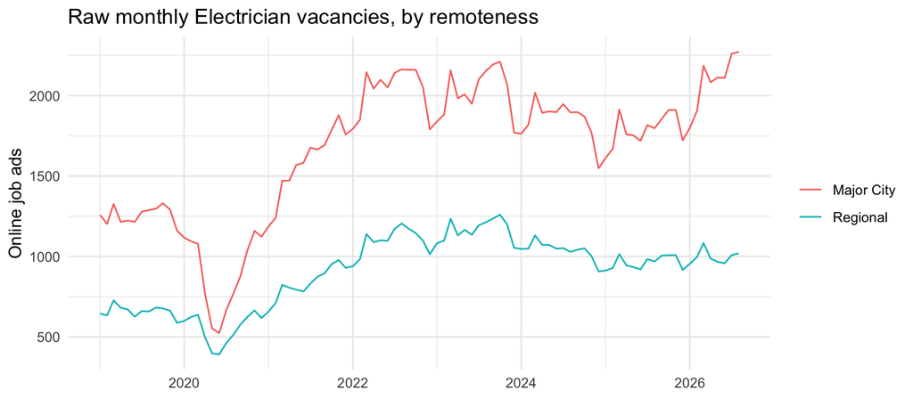

```r
ggplot(elec_ivi, aes(x = date, y = vacancies, colour = remoteness)) +
  geom_line() +
  labs(title = "Raw monthly Electrician vacancies, by remoteness",
       x = NULL, y = "Online job ads", colour = NULL) +
  theme_minimal()
```

```r
ivi_annual <- elec_ivi %>%
  filter(year >= 2019, year <= 2025) %>%
  group_by(remoteness, year) %>%
  summarise(vacancies = sum(vacancies), .groups = "drop")

ivi_annual
```

```
## # A tibble: 14 × 3
##    remoteness  year vacancies
##    <chr>      <dbl>     <dbl>
##  1 Major City  2019     15087
##  2 Major City  2020     10759
##  3 Major City  2021     18978
##  4 Major City  2022     24448
##  5 Major City  2023     24319
##  6 Major City  2024     22219
##  7 Major City  2025     21441
##  8 Regional    2019      7915
##  9 Regional    2020      6604
## 10 Regional    2021     10038
## 11 Regional    2022     13157
## 12 Regional    2023     14004
## 13 Regional    2024     12503
## 14 Regional    2025     11547
```

2026 is excluded as it is a partial year (data to August only) and would distort a year-over-year growth calculation.

### 3.3 NCVER completions (supply side)

```r
ncver_path <- "Total_VET_students_and_courses_2025.xlsx"

ncv_raw <- read_excel(ncver_path, sheet = "Pivot Data", col_names = FALSE)
header <- as.character(unlist(ncv_raw[1, ]))
data_rows <- ncv_raw[4:10, ]   # the 7 remoteness breakdown rows
colnames(data_rows) <- header

ncver_long <- data_rows %>%
  rename(training_package = 2, remoteness_ncver = 3) %>%
  select(-1) %>%
  pivot_longer(-c(training_package, remoteness_ncver), names_to = "year", values_to = "completions") %>%
  mutate(year = as.numeric(year), completions = as.numeric(completions))

ncver_long
```

```
## # A tibble: 49 × 4
##    training_package                  remoteness_ncver  year completions
##    <chr>                             <chr>            <dbl>       <dbl>
##  1 Electrotechnology (UEE, UTE, UTL) Major cities      2019       10575
##  2 Electrotechnology (UEE, UTE, UTL) Major cities      2020       11000
##  3 Electrotechnology (UEE, UTE, UTL) Major cities      2021       12340
##  4 Electrotechnology (UEE, UTE, UTL) Major cities      2022       13640
##  5 Electrotechnology (UEE, UTE, UTL) Major cities      2023       12650
##  6 Electrotechnology (UEE, UTE, UTL) Major cities      2024       14250
##  7 Electrotechnology (UEE, UTE, UTL) Major cities      2025       17180
##  8 Electrotechnology (UEE, UTE, UTL) Inner regional    2019        2635
##  9 Electrotechnology (UEE, UTE, UTL) Inner regional    2020        2675
## 10 Electrotechnology (UEE, UTE, UTL) Inner regional    2021        3030
## # ℹ 39 more rows
```

### 3.4 Harmonising geography

IVI classifies regions as a binary **Major City / Regional** split. NCVER’s DataBuilder exposes a finer 7-category remoteness classification. To join the two datasets, the NCVER categories are collapsed as follows:

- `Major cities` -> **Major City**
- `Inner regional`, `Outer regional`, `Remote`, `Very remote` -> **Regional**
- `Offshore`, `Not known` -> **excluded** (together ~4.5% of total completions; these do not correspond to any IVI remoteness category and cannot be reliably allocated to either side of the binary split)

```r
ncver_annual <- ncver_long %>%
  mutate(remoteness = case_when(
    remoteness_ncver == "Major cities" ~ "Major City",
    remoteness_ncver %in% c("Inner regional", "Outer regional", "Remote", "Very remote") ~ "Regional",
    TRUE ~ "Exclude"
  )) %>%
  filter(remoteness != "Exclude") %>%
  group_by(remoteness, year) %>%
  summarise(completions = sum(completions), .groups = "drop")

excl_pct <- ncver_long %>%
  mutate(excl = remoteness_ncver %in% c("Offshore", "Not known")) %>%
  summarise(pct = 100 * sum(completions[excl]) / sum(completions))
cat("Share of completions excluded by harmonisation:", round(excl_pct$pct, 1), "%\n")
```

```
## Share of completions excluded by harmonisation: 4.5 %
```

```r
ncver_annual
```

```
## # A tibble: 14 × 3
##    remoteness  year completions
##    <chr>      <dbl>       <dbl>
##  1 Major City  2019       10575
##  2 Major City  2020       11000
##  3 Major City  2021       12340
##  4 Major City  2022       13640
##  5 Major City  2023       12650
##  6 Major City  2024       14250
##  7 Major City  2025       17180
##  8 Regional    2019        4430
##  9 Regional    2020        4425
## 10 Regional    2021        5160
## 11 Regional    2022        6185
## 12 Regional    2023        5955
## 13 Regional    2024        6915
## 14 Regional    2025        8140
```

## 4. Combining demand and supply, and computing the divergence score

```r
combined <- ivi_annual %>%
  inner_join(ncver_annual, by = c("remoteness", "year")) %>%
  group_by(remoteness) %>%
  arrange(year) %>%
  mutate(
    vacancy_growth    = (vacancies   - lag(vacancies))   / lag(vacancies)   * 100,
    completion_growth = (completions - lag(completions)) / lag(completions) * 100,
    divergence = vacancy_growth - completion_growth
  ) %>%
  ungroup()

combined %>%
  mutate(across(where(is.numeric), ~round(., 1))) %>%
  as.data.frame()
```

```
##    remoteness year vacancies completions vacancy_growth completion_growth
## 1  Major City 2019     15087       10575             NA                NA
## 2    Regional 2019      7915        4430             NA                NA
## 3  Major City 2020     10759       11000          -28.7               4.0
## 4    Regional 2020      6604        4425          -16.6              -0.1
## 5  Major City 2021     18978       12340           76.4              12.2
## 6    Regional 2021     10038        5160           52.0              16.6
## 7  Major City 2022     24448       13640           28.8              10.5
## 8    Regional 2022     13157        6185           31.1              19.9
## 9  Major City 2023     24319       12650           -0.5              -7.3
## 10   Regional 2023     14004        5955            6.4              -3.7
## 11 Major City 2024     22219       14250           -8.6              12.6
## 12   Regional 2024     12503        6915          -10.7              16.1
## 13 Major City 2025     21441       17180           -3.5              20.6
## 14   Regional 2025     11547        8140           -7.6              17.7
##    divergence
## 1          NA
## 2          NA
## 3       -32.7
## 4       -16.5
## 5        64.2
## 6        35.4
## 7        18.3
## 8        11.2
## 9         6.7
## 10       10.2
## 11      -21.3
## 12      -26.8
## 13      -24.1
## 14      -25.4
```

The **divergence score** is defined as:

$$\text{divergence}_t = \text{vacancy
growth rate}_t - \text{completion growth rate}_t$$

A positive score means vacancy demand grew faster than training completions that year (the gap is widening); a negative score means completions grew faster than vacancies (the gap is narrowing). This is the core novel contribution of the proposed system: existing resources compare demand and supply **levels**, but none compute or track this *rate-of-change* signal over time.

## 5. Visualising the result

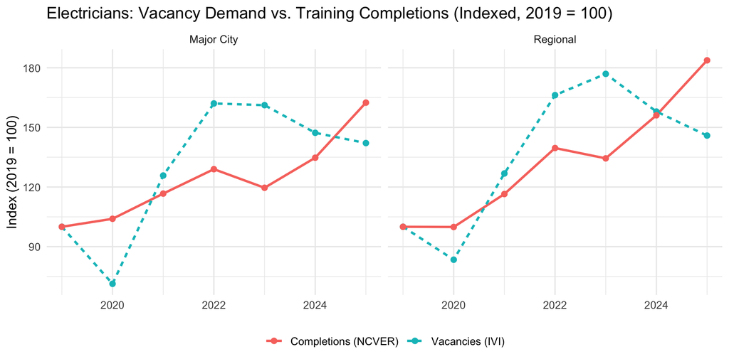

```r
indexed <- combined %>%
  group_by(remoteness) %>%
  arrange(year) %>%
  mutate(vac_index = vacancies / first(vacancies) * 100,
         comp_index = completions / first(completions) * 100) %>%
  select(remoteness, year, vac_index, comp_index) %>%
  pivot_longer(c(vac_index, comp_index), names_to = "series", values_to = "index") %>%
  mutate(series = recode(series, vac_index = "Vacancies (IVI)", comp_index = "Completions (NCVER)"))

ggplot(indexed, aes(x = year, y = index, colour = series, linetype = series)) +
  geom_line(linewidth = 1) + geom_point(size = 2) +
  facet_wrap(~remoteness) +
  labs(title = "Electricians: Vacancy Demand vs. Training Completions (Indexed, 2019 = 100)",
       x = NULL, y = "Index (2019 = 100)", colour = NULL, linetype = NULL) +
  theme_minimal(base_size = 12) +
  theme(legend.position = "bottom")
```

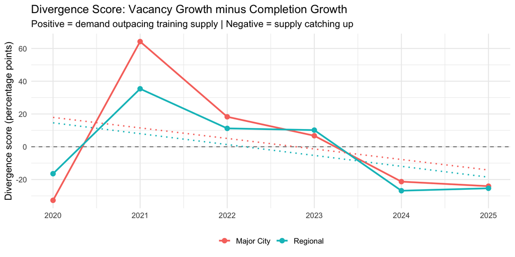

```r
div_data <- combined %>% filter(!is.na(divergence))

ggplot(div_data, aes(x = year, y = divergence, colour = remoteness)) +
  geom_hline(yintercept = 0, linetype = "dashed", colour = "grey50") +
  geom_line(linewidth = 1) + geom_point(size = 2.5) +
  geom_smooth(method = "lm", se = FALSE, linetype = "dotted", linewidth = 0.8) +
  labs(title = "Divergence Score: Vacancy Growth minus Completion Growth",
       subtitle = "Positive = demand outpacing training supply | Negative = supply catching up",
       x = NULL, y = "Divergence score (percentage points)", colour = NULL) +
  theme_minimal(base_size = 12) +
  theme(legend.position = "bottom")
```

## 6. Trend analysis

```r
for (r in unique(combined$remoteness)) {
  sub <- combined %>% filter(remoteness == r, !is.na(divergence))
  fit <- lm(divergence ~ year, data = sub)
  s <- summary(fit)
  cat(sprintf("%s: slope = %.2f pp/year, p-value = %.3f, R-squared = %.3f (n = %d)\n",
              r, coef(fit)[2], s$coefficients[2,4], s$r.squared, nrow(sub)))
}
```

```
## Major City: slope = -6.42 pp/year, p-value = 0.521, R-squared = 0.110 (n = 6)
## Regional: slope = -6.64 pp/year, p-value = 0.313, R-squared = 0.249 (n = 6)
```

## 7. Interpretation

For Electricians, the divergence score follows a consistent pattern in **both** Major City and Regional areas: a large positive spike in 2021 (vacancies rebounded far faster than training completions after the 2020 COVID dip), tapering through 2022-2023, and turning **negative** from 2024 onward (completions now growing faster than vacancies in both regions). The fitted linear trend is negative for both regions (approximately -6.4 to -6.6 percentage points per year), consistent with a mismatch that is **narrowing** rather than widening over the observed period - the opposite direction to a worsening shortage, and a genuinely useful signal that a simple “current gap” comparison would not surface.

**Statistical caveat:** with only six year-over-year observations per region, the trend slopes are not statistically signficant at conventional thresholds (p = 0.52 for Major City, p = 0.31 for Regional), and R-squared is modest. This is expected given the sample size and the real-world volatility of the COVID-affected period. The method is represented here as a **directional, feasibility-level indicator** rather than a statistically validated forecast; a production version of this system would need longer and more granular (e.g., quarterly) series to support stronger statistical claims.

## 8. Feasibility conclusion

This demonstration confirms the core mechanism proposed in the project report is technically feasible with real, publicly available Australian data:

1. Both data sources can be acquired, reshaped, and joined on a common occupation/region/year key.
2. A genuine divergence (rate-of-change) signal - not just a static level comparison - can be computed and visualised.
3. The resulting signal is interpretable and tells a substantively different story than either raw series alone: it correctly identifies that the Electricians training pipeline, after lagging during the COVID-era demand surge, has since caught up and is now outpacing vacancy growth.

A full production system would extend this single-occupation proof of concept across the full ANZSCO occupation set, automate the NCVER DataBuilder extraction, and incorporate quarterly or monthly completions data where available to improve statistical power.